# Penguins In Class Activity

Josh Winnes

2025-01-20

# Looking at the data

Using a markdown like this is a great way to follow along as you read from the [R for Data Science](https://r4ds.hadley.nz) or Tidy Modeling with R books. It allows you to write text (to keep notes) along with your code. Here we are going to load the `palmerpenguins` data into our environment:

```r
data(penguins)
```

Notice that the `penguins` data set now appears in the Environment tab on the upper right of our screen. We can get a look at the data using the `glimpse` function:

```r
glimpse(penguins)
```

```
## Rows: 344
## Columns: 8
## $ species           <fct> Adelie, Adelie, Adelie, Adelie, Adelie, Adelie, Adel…
## $ island            <fct> Torgersen, Torgersen, Torgersen, Torgersen, Torgerse…
## $ bill_length_mm    <dbl> 39.1, 39.5, 40.3, NA, 36.7, 39.3, 38.9, 39.2, 34.1, …
## $ bill_depth_mm     <dbl> 18.7, 17.4, 18.0, NA, 19.3, 20.6, 17.8, 19.6, 18.1, …
## $ flipper_length_mm <int> 181, 186, 195, NA, 193, 190, 181, 195, 193, 190, 186…
## $ body_mass_g       <int> 3750, 3800, 3250, NA, 3450, 3650, 3625, 4675, 3475, …
## $ sex               <fct> male, female, female, NA, female, male, female, male…
## $ year              <int> 2007, 2007, 2007, 2007, 2007, 2007, 2007, 2007, 2007…
```

If you want to inspect a little more closely, click the `penguins` data in your Environment pane on the upper right side of the screen.

What do all these variables mean? This data is well-documented, so we can find out more using `?penguins`. Try typing that yourself in the console, and see what happens. We’ll get more into importing and wrangling data later on.

One more note: the beginning of each code chunk looks like `{r chunk-name}`. The first `r` just indicates that we are using `R` code, but other languages like python are supported as well! The `chunk-name` is important, too, because it tells you where to look if you make errors!

# First Plot

Use this section to follow along with [Chapter 1 of R4DS](https://r4ds.hadley.nz/data-visualize). Make a new chunk to run code from the chapter, and eventually you should make this image:

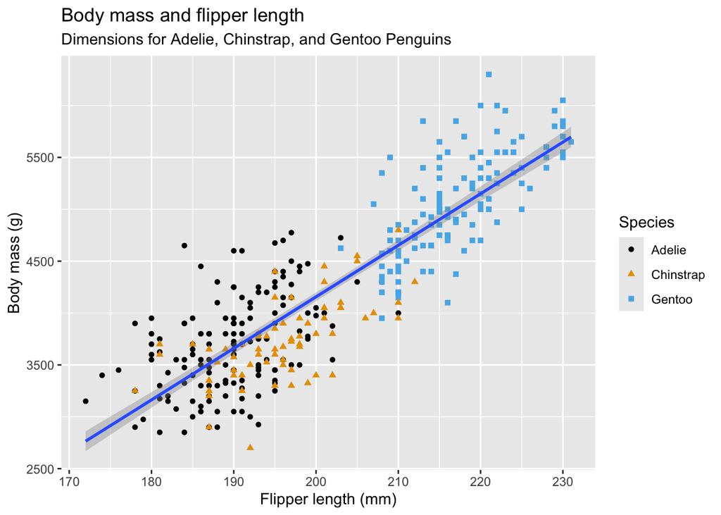

```r
ggplot(
  data = penguins,
  mapping = aes(x = flipper_length_mm, y = body_mass_g)
) +
  geom_point(aes(color = species, shape = species)) +
  geom_smooth(method = "lm") +
  labs(
    title = "Body mass and flipper length",
    subtitle = "Dimensions for Adelie, Chinstrap, and Gentoo Penguins",
    x = "Flipper length (mm)", y = "Body mass (g)",
    color = "Species", shape = "Species"
  ) +
  scale_color_colorblind()
```

# Second Plot

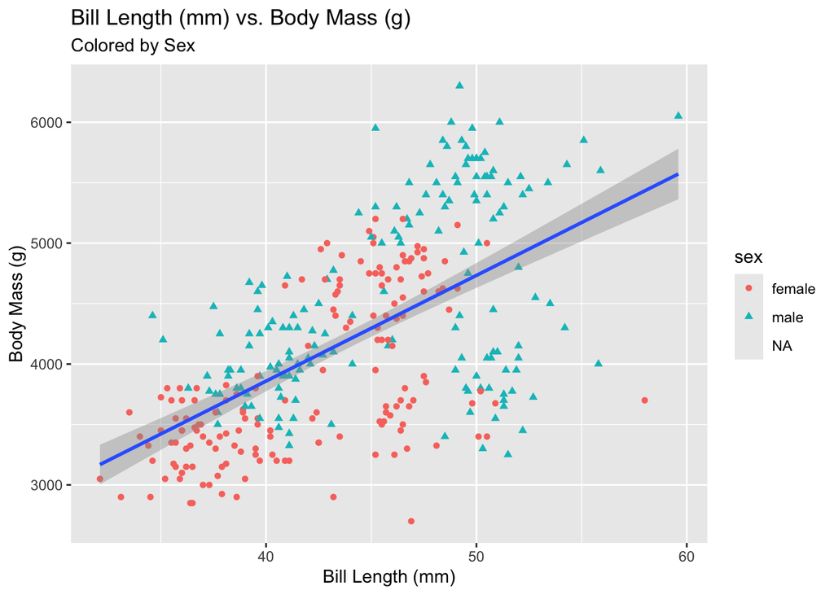

```r
ggplot(data=penguins,
       mapping = aes(x=bill_length_mm, y=body_mass_g),
       ) +
  geom_point(mapping = aes(color=sex, shape=sex)) +
  geom_smooth(method="lm")+
  labs(
    title="Bill Length (mm) vs. Body Mass (g)",
    subtitle = "Colored by Sex",
    x = "Bill Length (mm)", y = "Body Mass (g)"
  )
```

# Third Plot

[figure not shown]

# Testing some stuff in class

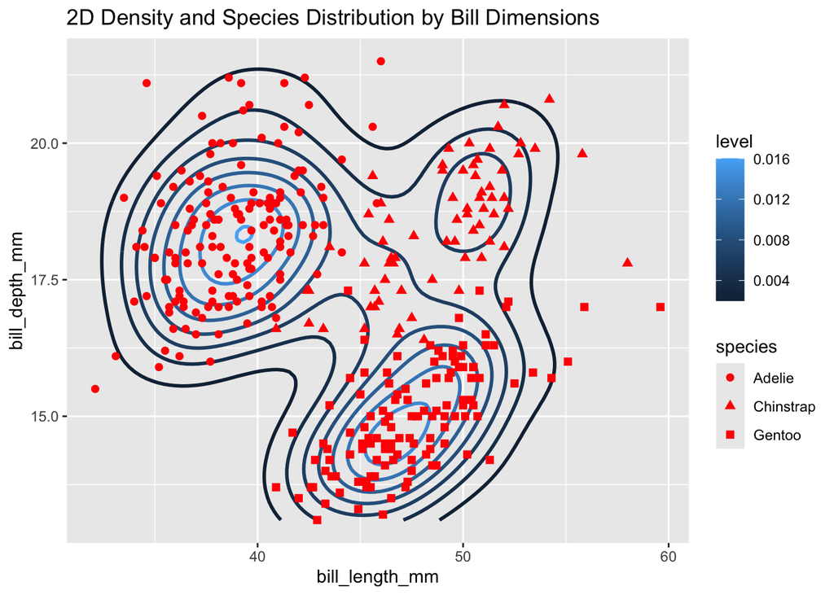

```r
plot <- ggplot(penguins, aes(x = bill_length_mm, y = bill_depth_mm)) +
  geom_density_2d(aes(color = stat(level)), linewidth=1) +
  geom_point(aes(shape = species), color='red', size=2) +
  labs(
    title = '2D Density and Species Distribution by Bill Dimensions'
  )

plot
```

# Visualizations

### Plot 1

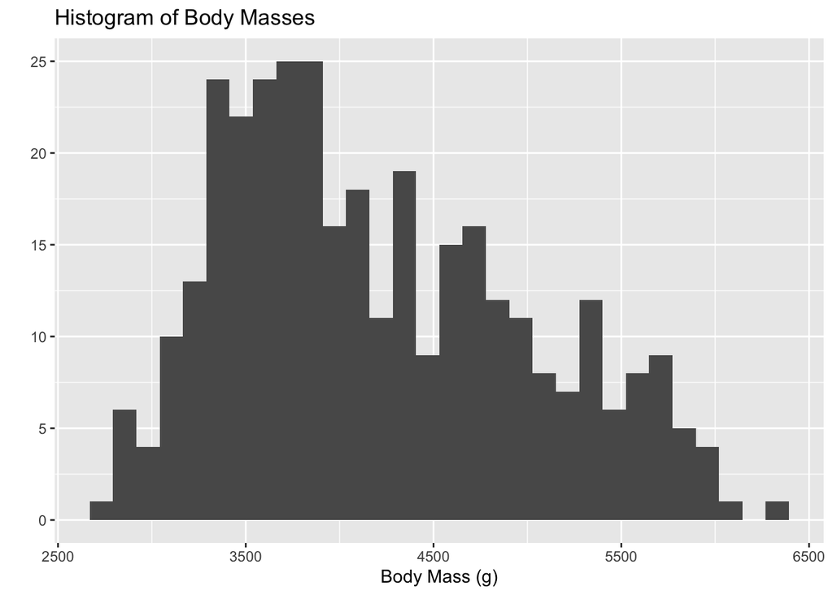

```r
plot <- ggplot(penguins, aes(x=body_mass_g))

plot +
  geom_histogram(bins = 30) +
  labs(
    title = "Histogram of Body Masses",
    x = "Body Mass (g)",
    y = ""
  )
```

### Plot 2

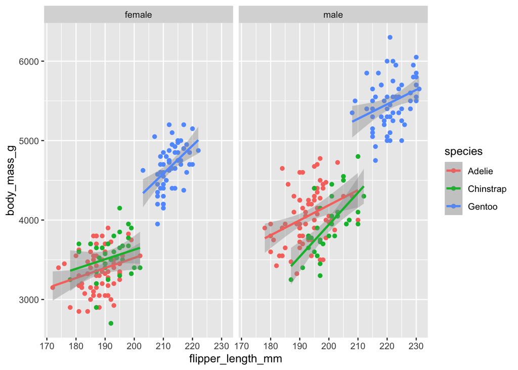

```r
plot2 <- ggplot(penguins %>% filter(!is.na(sex)), aes(x=flipper_length_mm, y=body_mass_g, color=species))

plot2 +
  facet_wrap(~sex)+
  geom_point()+
  geom_smooth(method="lm")
```

### Plot 3

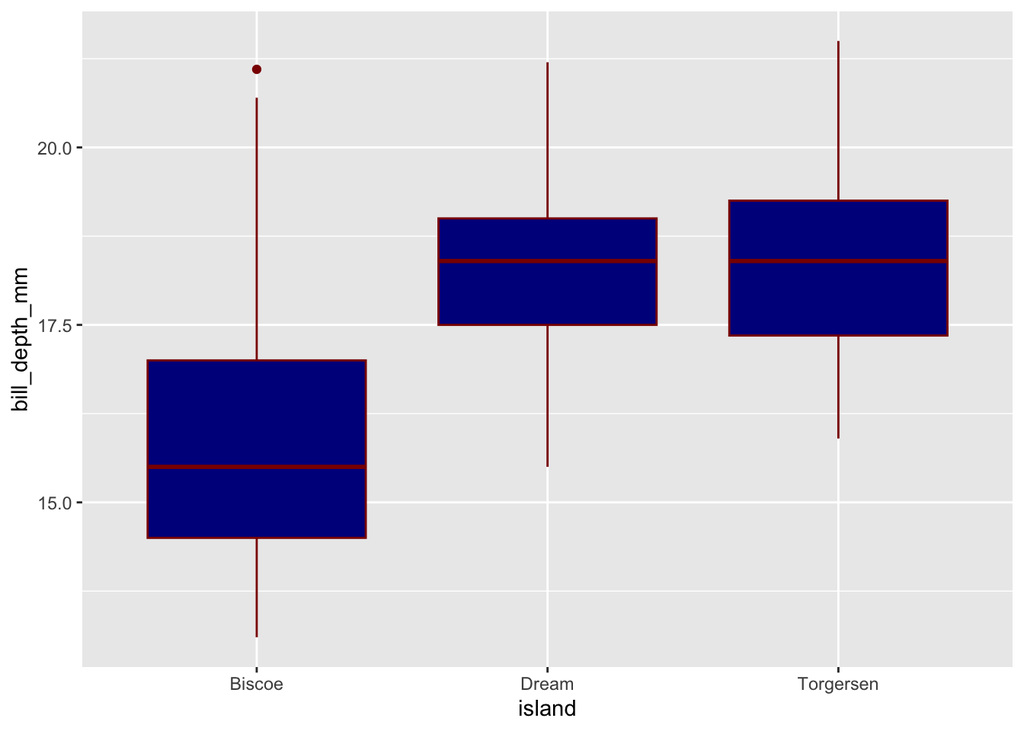

```r
plot3 <- ggplot(penguins, aes(x=island, y=bill_depth_mm))

plot3 +
  geom_boxplot(
    fill = "darkblue",
    color = "darkred"
  )
```